# Exploratory Data Analysis

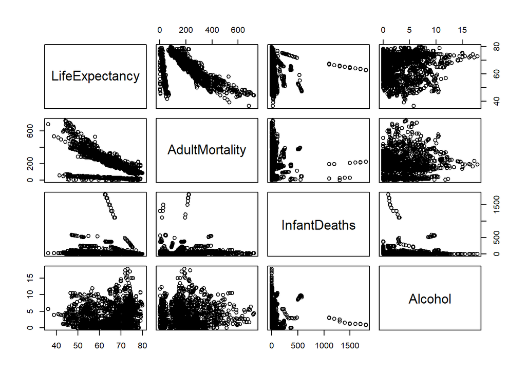

```r
pairs(le_developing[,c(4:7)])
```

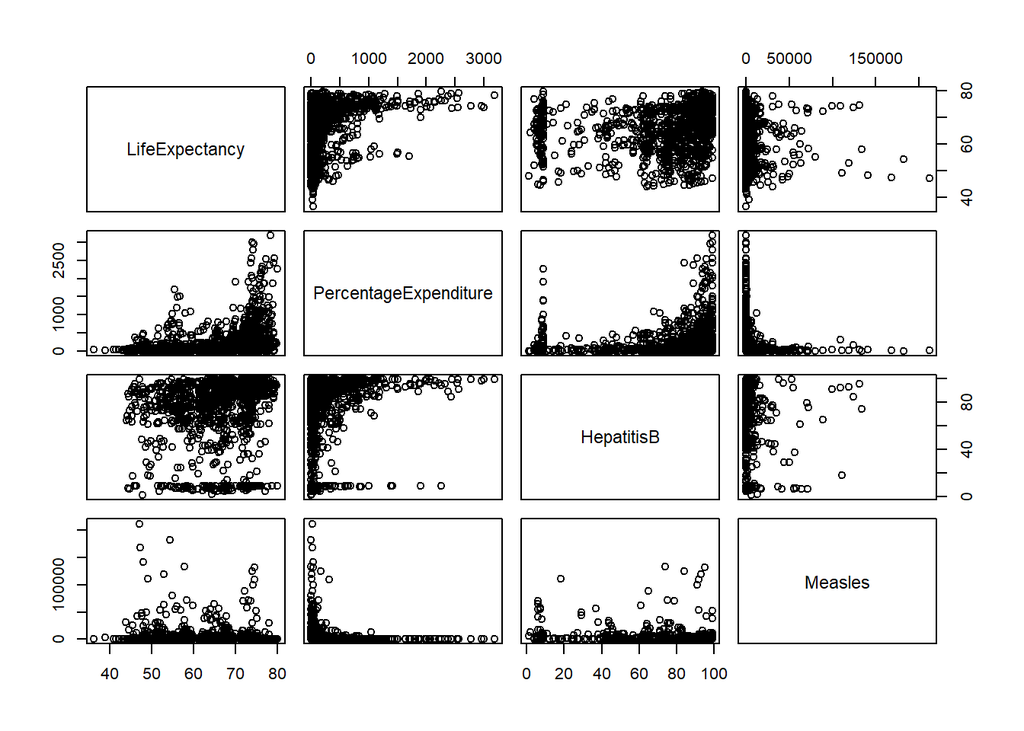

```r
pairs(le_developing[,c(4,8:10)])
```

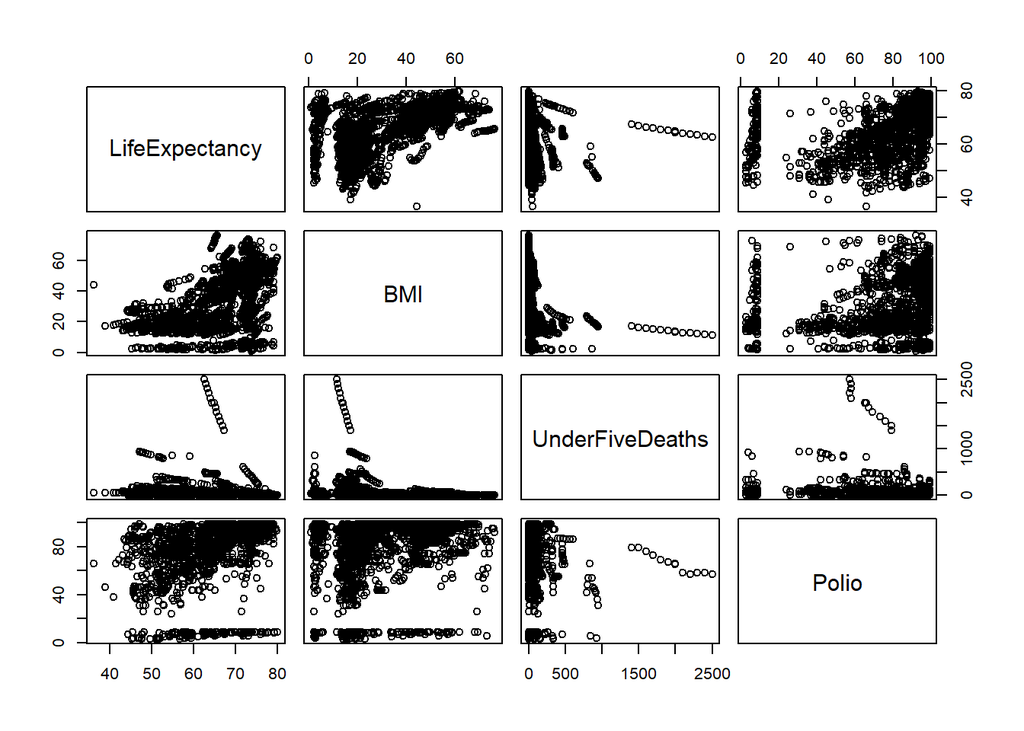

```r
pairs(le_developing[,c(4,11:13)])
```

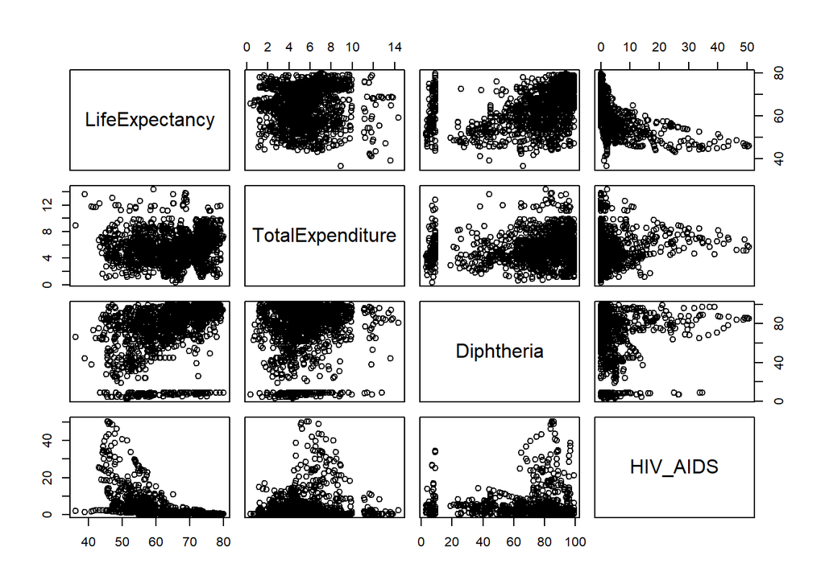

```r
pairs(le_developing[,c(4,14:16)])
```

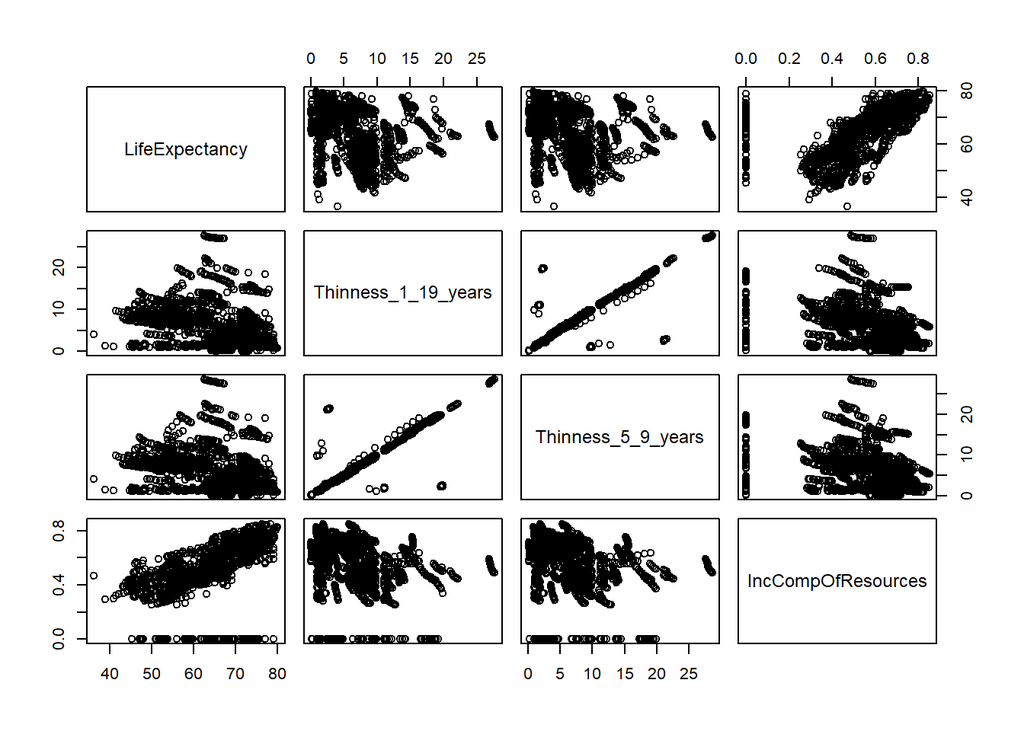

```r
pairs(le_developing[,c(4,17:19)])
```

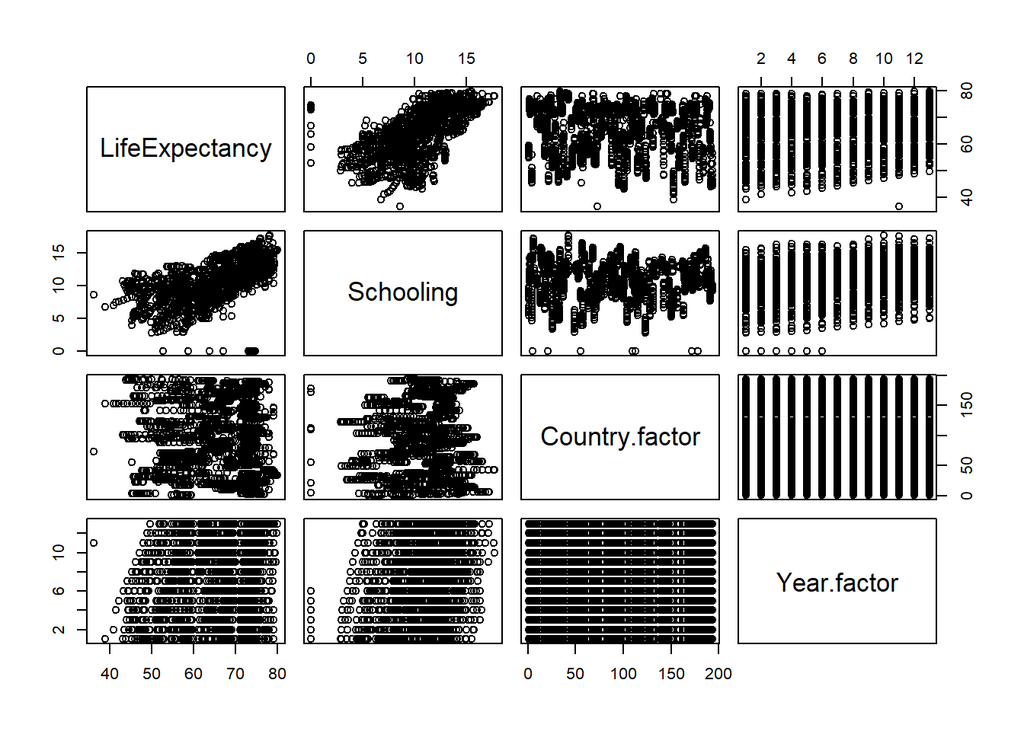

```r
pairs(le_developing[,c(4,20:22)])
```

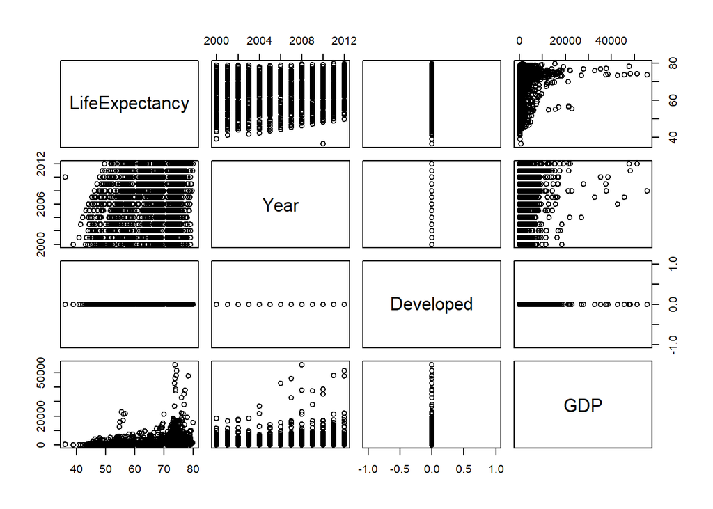

```r
pairs(le_developing[,c(4,2,23,24)])
```

# Fitting the models (re-using code from RLab4.R that was provided in unit 6)

# Setting up for model creation and creating training and validation sets

```r
# Seed will be set before data partition and each model creation so that we can run pieces of code independently and obtain predictable results
set.seed(1234)

# These columns names will be used for parametric models
life_expectancy$log_LifeExpectancy <- life_expectancy$`log(LifeExpectancy)`
life_expectancy$log_HIV_AIDS <- life_expectancy$`log(HIV_AIDS)`
life_expectancy$log_GDP <- life_expectancy$`log(GDP)`

# Setup of CV details
fitControl<-trainControl(method="repeatedcv",number=10,repeats=10) #number is the k in k-fold

# Creating training and validation set
trainIndex<-createDataPartition(life_expectancy$LifeExpectancy,p=.85,list=F)  #p: proportion of data in train

training<-life_expectancy[trainIndex,]
validate<-life_expectancy[-trainIndex,]
```

# Creating GLM Net Model (selecting tuning parameters alpha and lambda via 10 FOLD CV))

Our model contains 17 predictors, which can be a fair number of predictors. We need to attempt a regulation method to reduce our potential predictors? We’ll use elastic-net regression to use the least squares and combines the Lasso Regression Penalty and Ridge Regression Penalty.

We’ll use cross validation on various lambdas for the two penalties to determine the best values. If both penalty lambdas are reduced to 0, we should get the original least squares parameter estimates.

Otherwise, if the penalty lambdas are not 0, we can get the potential following: * lambda_1 > 0 and lambda_2 = 0 –> LASSO regression * lambda_1 = 0 and lambda_2 > 0 –> Ridge regression * lambda_1 > 0 and lambda_2 > 0 –> Hybrid of LASSO and Ridge Regression ** Ideal for dealing w/ correlation between parameters as we should be able to group and shrink parameters that are correlated

```r
set.seed(1234)

# TODO: I added "na.action=na.exclude" but not sure if we should keep it (need to figure out what is excluded exactly)

glmnet.fit<-train(log_LifeExpectancy~Developed+Year+AdultMortality+InfantDeaths+Alcohol+HepatitisB+Measles+BMI+Polio+TotalExpenditure+Diphtheria+log_HIV_AIDS+log_GDP+Population+Thinness_1_19_years+IncCompOfResources+Schooling,
               data=training,
               method="glmnet",
               trControl=fitControl,
               na.action=na.exclude
               )

#Lets look at the results of what this model has decided on
glmnet.fit
```

[output not shown]

```r
#Here we can see exactly what the estimated f(x) looks like.
coef(glmnet.fit$finalModel,glmnet.fit$finalModel$lambdaOpt)
```

```
## 18 x 1 sparse Matrix of class "dgCMatrix"
##                                 1
## (Intercept)          3.578602e+00
## Developed            1.077227e-02
## Year                 2.226135e-04
## AdultMortality      -2.580283e-04
## InfantDeaths        -3.875552e-05
## Alcohol              5.998347e-04
## HepatitisB           .
## Measles              .
## BMI                  .
## Polio                4.264441e-05
## TotalExpenditure     1.734147e-05
## Diphtheria           2.300679e-04
## log_HIV_AIDS        -3.728875e-02
## log_GDP              5.869526e-03
## Population           .
## Thinness_1_19_years -9.743322e-04
## IncCompOfResources   8.914382e-02
## Schooling            6.578067e-03
```

```r
#Lets take a look at how well the predictions look by calculating the validation RMSE as well as simple plotting strategy.
glmnet.pred<-predict(glmnet.fit,validate)

glmnet.RMSE<-sqrt(mean((validate$LifeExpectancy-glmnet.pred)^2))
# TODO: Figure out error below:
# plot(glmnet.pred,validate$LifeExpectancy,ylim=c(0,3000),xlim=c(0,3000))
#lines(0:2000,0:2000)
glmnet.RMSE
```

```
## [1] 65.42493
```

```r
#Here is a more natural tool to compute RMSE as well as some additional metrics
glmnet.validate<-postResample(pred = glmnet.pred, obs = validate$LifeExpectancy)
glmnet.validate
```

```
##     RMSE Rsquared      MAE
## 65.42493       NA 64.71783
```

```r
#Ranking of the predictors
varImp(glmnet.fit)
```

```
## glmnet variable importance
##
##                       Overall
## IncCompOfResources  100.00000
## log_HIV_AIDS         41.82987
## Developed            12.08415
## Schooling             7.37916
## log_GDP               6.58433
## Thinness_1_19_years   1.09299
## Alcohol               0.67288
## AdultMortality        0.28945
## Diphtheria            0.25809
## Year                  0.24972
## Polio                 0.04784
## InfantDeaths          0.04348
## TotalExpenditure      0.01945
## BMI                   0.00000
## Measles               0.00000
## Population            0.00000
## HepatitisB            0.00000
```

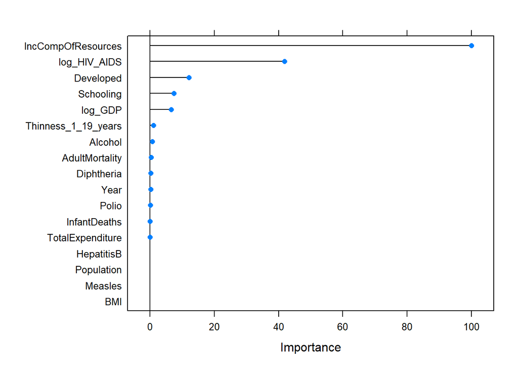

```r
plot(varImp(glmnet.fit))
```